# Time Series Homework: Chapter 1 Lesson 3 Key

## Data

```r
# Macroeconomic Data: unemployment rate
unemp_rate <- rio::import("https://byuistats.github.io/timeseries/data/unemp_rate.csv")
```

## Questions

### Question 1 - Estimating the Trend: Centered Moving Average (10 points)

Please plot the US Unemployment time series and superimpose the centered moving average series $\hat{m}_{t}$ in the same graph. Don’t use an R command; rather, do it by coding $\hat{m}_{t}$ like in Chapter 1: Lesson 3. Use the appropriate axis labels, units, and captions.

**Answer**

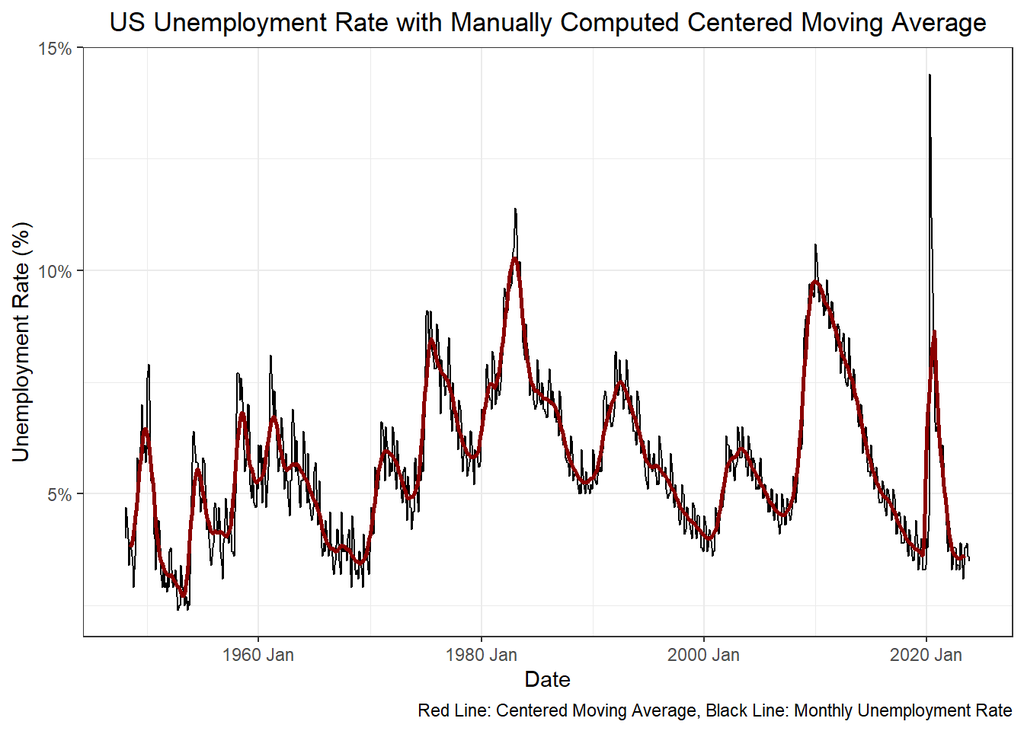

```r
# Please provide your code here
# Create a tibble (data frame) with necessary columns from the original 'unemp_rate' dataset
# Extract 'date' and 'value' columns, and derive 'year' and 'month' using lubridate
unemp_rate.t <- tibble(
  dates = pull(unemp_rate, date),  # Extract 'date' column
  year = lubridate::year(pull(unemp_rate, date)),  # Extract the year from 'date'
  month = lubridate::month(pull(unemp_rate, date)),  # Extract the month from 'date'
  value = pull(unemp_rate, value)  # Extract 'value' column (unemployment rate)
)

# Convert to a 'tsibble' (time series tibble) and calculate the 'line_value' using lag and lead values
unemp_rate_ts <- unemp_rate.t %>%
  # Create a new 'index' column for time series using 'yearmonth' (for monthly data)
  mutate(index = tsibble::yearmonth(dates),
         # Calculate 'line_value' as the average of the current value, past 6 months (lag), and next 6 months (lead)
         line_value = (0.5 * lag(value, 6, default = NA) +  # 6 months prior, weighted by 0.5
                       lag(value, 5, default = NA) +  # 5 months prior
                       lag(value, 4, default = NA) +  # 4 months prior
                       lag(value, 3, default = NA) +  # 3 months prior
                       lag(value, 2, default = NA) +  # 2 months prior
                       lag(value, 1, default = NA) +  # 1 month prior
                       value +  # Current value
                       lead(value, 1, default = NA) +  # 1 month ahead
                       lead(value, 2, default = NA) +  # 2 months ahead
                       lead(value, 3, default = NA) +  # 3 months ahead
                       lead(value, 4, default = NA) +  # 4 months ahead
                       lead(value, 5, default = NA) +  # 5 months ahead
                       0.5 * lead(value, 6, default = NA)) / 12) %>%  # 6 months ahead, weighted by 0.5, then average over 12
  as_tsibble(index = index)  # Convert the resulting data frame into a tsibble, using 'index' as the time index

# Plot the unemployment rate data
autoplot(unemp_rate_ts, value) +  # Plot the unemployment rate ('value') from the tsibble
  # Add a line representing the 'line_value' (smoothed data) to the graph
  geom_line(data = unemp_rate_ts,
            aes(x = index, y = line_value),  # Map 'index' (dates) and 'line_value' (smoothed data)
            color = "red4",  # Line color set to red
            size = 1) +  # Set line thickness
  # Add labels to the plot
  labs(
    x = "Date",  # X-axis label
    y = "Unemployment Rate (%)",  # Y-axis label
    title = "US Unemployment Rate with Manually Computed Centered Moving Average",  # Plot title
    caption = "Red Line: Centered Moving Average, Black Line: Monthly Unemployment Rate"
  ) +
  # Set Y-axis to percentage format
  scale_y_continuous(labels = scales::percent_format(scale = 1)) +  # Display y-axis values as percentages
  # Use a clean black and white theme
  theme_bw() +
  # Center the plot title
  theme(plot.title = element_text(hjust = 0.5))
```

### Question 2 - Seasonal Averages: Side-by-Side Box Plots by Month (10 points)

Please create a box plot to illustrate the monthly averages in the US Unemployment time series. Use the appropriate axis labels, units, and captions.

**Answer**

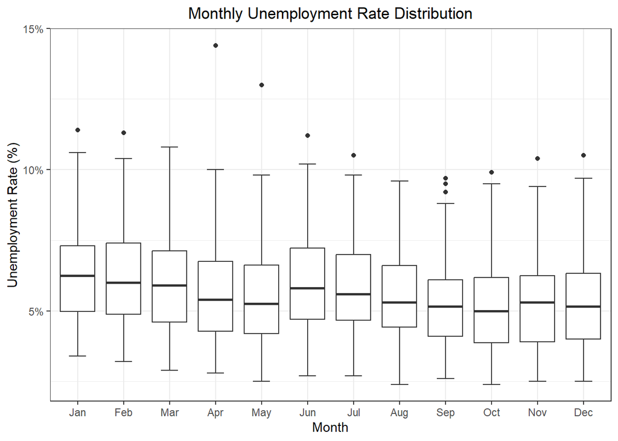

```r
# Please provide your code here
# Please provide your code here

# Calculate monthly averages across all years
monthly_avg <- unemp_rate.t %>%
  group_by(month) %>%  # Group by month
  summarise(average_value = mean(value, na.rm = TRUE))  # Calculate the average unemployment rate for each month

# Create a box plot of monthly averages
plot1 <- ggplot(unemp_rate.t, aes(x = factor(month), y = value)) +  # X-axis: month, Y-axis: unemployment rate
  geom_boxplot(staplewidth = 0.5) +  # Create the box plot
  labs(
    x = "Month",  # X-axis label
    y = "Unemployment Rate (%)",  # Y-axis label
    title = "Monthly Unemployment Rate Distribution"  # Plot title
  ) +
  scale_x_discrete(labels = month.abb) +  # Label X-axis with month names
  scale_y_continuous(labels = scales::percent_format(scale = 1)) +  # Format Y-axis as percentages
  theme_bw() +  # Use a clean black-and-white theme
  theme(plot.title = element_text(hjust = 0.5))  # Center the plot title
plot1
```

### Question 3 - Seasonal Averages: Analysis (20 points)

##### a) Describe the seasonality of the US unemployment time series. Comment on the series’ periods of highest and lowest unemployment. Are there any notable outliers?

**Answer**

Here in the box plot we can see that the highest median unemployment rates are typically around the beginning of the year from January to Februrary, then later in the year, June and July have higher unemployment rates once again. The periods with the lowest unemployment range from April and May, as well as September and October. The unemployment values here can be due to seasonal employment patterns. One noticiable outlier here is found in the month of April. In April 2020, the highest unemployment rate was ever recorded due to the COVID pandemic. However, there doesn’t seem to be a month that has a significantly higher unemployment rate than the other.

##### b) Please explain the patterns you found. Include information from your prior research on the series.

**Answer**

Perhaps one reason as to why there are increases in unemployment rates at the beginning of the year and towards the summer months is because certain industries experience significant employment fluctuations due to seasonal demand for workers.

Another clear example is a wave of new job seekers enters the market around this time as recent high school and college graduates begin looking for work. Since it can take some time for these individuals to secure employment, it temporarily drives up unemployment rates. Additionally, there is rise in unemployment before switching to summer months, largely due to shifts in industries like agriculture and tourism, where jobs often peak or wind down, leading to employment changes.

### Rubric

[output not shown]